# Reproducible Research: Peer Assessment 1

## What is mean total number of steps taken per day?

I calcualted the total steaps taken each day by groupping and summerising the data. Read data in from: https://d396qusza40orc.cloudfront.net/repdata%2Fdata%2Factivity.zip using read_csv. Most of my code uses the tityverse conventions and libraries.

1. Code for reading in data to a dataframe/tibble here:

```r
activity <- read_csv("./data/activity.zip", col_names = TRUE, col_types = "nDn")
```

2. Histogram of the total number of steps taked per day

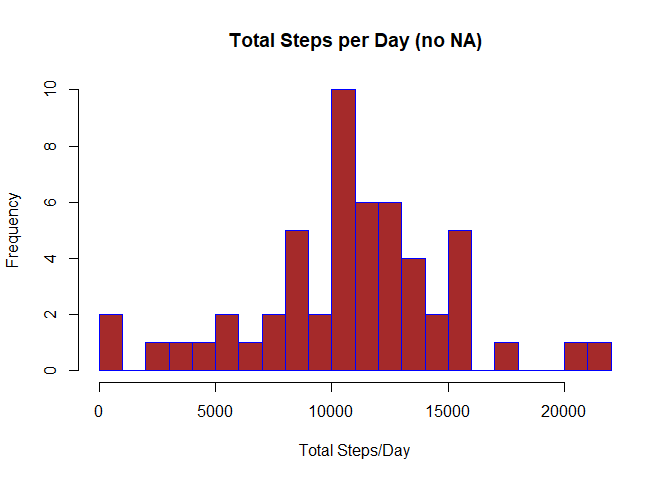

```r
activity %>% group_by(date) %>% summarise(SPD = sum(steps)) -> result1

hist(result1$SPD, main = "Total Steps per Day (no NA)", xlab = "Total Steps/Day", border = "blue", col = "brown", breaks = 20)
```

3. This table shows a summery of Steps per day (SPD) recorded per day:

```r
as.numeric(sub('.*:', '', summary(result1)[3,2])) -> spd_median
as.numeric(sub('.*:', '', summary(result1)[4,2])) -> spd_mean
tibble(Result = c("Median", "Mean"), Value = c(spd_median, spd_mean)) -> spd_median_mean
spd_median_mean %>% kable(format = "html", table.attr = "style='width:30%;'") %>%
  kableExtra::kable_styling()
```

| Result | Value |
| --- | --- |
| Median | 10765 |
| Mean | 10766 |

## What is the average daily activity pattern?

Make a time series plot (type = “l”) of the 5-minute interval (x-axis) and the average number of steps taken, averaged across all days (y-axis)

4. This code developes the dataframe used for the timeseries plot, which is done in ggplot2 as a the line plot below

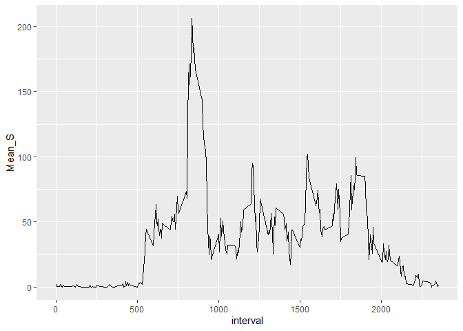

```r
activity %>% na.omit() %>% group_by(interval) %>% summarise(Mean_S = mean(steps)) -> steps_i

ggplot(steps_i, aes(x = interval, y = Mean_S)) +
  geom_line()
```

5. Which 5-minute interval, on average across all the days in the dataset, contains the maximum number of steps?

```r
steps_i %>% filter(Mean_S == max(steps_i$Mean_S)) -> max_i
```

Answer: the inerval with the average number of steps accross all days is: 835, and the maximun number of steps is: 206.1698113.

## Imputing missing values

6. The strategy for imputing vales was to first make a datafrom of average steps per interval. Pull out the missing step data and associated interval and then using match () fill in the missing data with average stes per all days for that interval. The activity_final contains the imuted and actual data combination.

```r
steps_na <- is.na(activity$steps)
activity_na <- activity[steps_na,]
interval_mean <-match(activity_na$interval, steps_i$interval)
activity_na$steps <- steps_i$Mean_S[interval_mean]
activity %>% na.omit() %>% rbind(activity_na) -> activity_final
```

7. Histogram of the total number of steps taken each day after missing values are imputed is shown here:

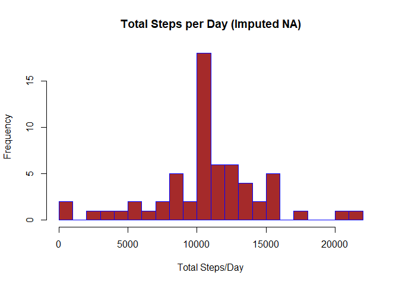

```r
activity_final %>% group_by(date) %>% summarise(SPD = sum(steps)) -> result2

hist(result2$SPD, main = "Total Steps per Day (Imputed NA)", xlab = "Total Steps/Day", border = "blue", col = "brown", breaks = 20)
```

```r
activity_final %>% filter(wday(date) == c(1,7)) %>% group_by(date) %>% summarise(SPD = sum(steps)) -> result3

activity_final %>% filter(wday(date) == c(2,3,4,5,6))   %>% group_by(date) %>% summarise(SPD = sum(steps)) -> result4
```

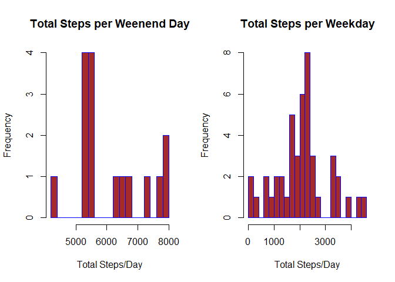

```r
par(mfcol=(c(1,2)))

hist(result3$SPD, main = "Total Steps per Weenend Day", xlab = "Total Steps/Day", border = "blue", col = "brown", breaks = 20)

hist(result4$SPD, main = "Total Steps per Weekday", xlab = "Total Steps/Day", border = "blue", col = "brown", breaks = 20)
```